# Introduction

Google Trends gives us an estimate of search volume. Let's explore if search popularity relates to other kinds of data. Perhaps there are patterns in Google's search volume and the price of Bitcoin or a hot stock like Tesla. Perhaps search volume for the term "Unemployment Benefits" can tell us something about the actual unemployment rate?

Data Sources:

- [Unemployment Rate from FRED](https://fred.stlouisfed.org/series/UNRATE/)
- [Google Trends](https://trends.google.com/trends/explore)
- [Yahoo Finance for Tesla Stock Price](https://finance.yahoo.com/quote/TSLA/history?p=TSLA)
- [Yahoo Finance for Bitcoin Stock Price](https://finance.yahoo.com/quote/BTC-USD/history?p=BTC-USD)

# Import Statements

```python
import pandas as pd
import matplotlib.pyplot as plt
```

# Read the Data

Download and add the .csv files to the same folder as your notebook.

```python
df_tesla = pd.read_csv('./Datasets/TESLA Search Trend vs Price.csv')

df_btc_search = pd.read_csv('./Datasets/Bitcoin Search Trend.csv')
df_btc_price = pd.read_csv('./Datasets/Daily Bitcoin Price.csv')

df_unemployment = pd.read_csv('./Datasets/UE Benefits Search vs UE Rate 2004-19.csv')
```

# Data Exploration:

### Tesla

**Challenge**:

- What are the shapes of the dataframes?
- How many rows and columns?
- What are the column names?
- Complete the f-string to show the largest/smallest number in the search data column
- Try the `.describe()` function to see some useful descriptive statistics
- What is the periodicity of the time series data (daily, weekly, monthly)?
- What does a value of 100 in the Google Trend search popularity actually mean?

```python
#=======================================================================Just looking at the Tesla Dataset==============================================================================#

    # Checing the shape/ Columns of the dataset
df_tesla.shape

    # No need to rename the columns to make it easier
df_tesla.columns
df_tesla.rename(columns = {"MONTH":"month",
                           "TSLA_WEB_SEARCH" : "search_results",
                           "TSLA_USD_CLOSE" : "closing_share_price" },
                inplace=True)

    # Checking the N/A Values
df_tesla.isna().sum()
            # Confirmed no missing values
    # Check the data types
df_tesla.dtypes
            # Need to convert the dates to datetime module instead of a list
df_tesla["month"]=pd.to_datetime(df_tesla["month"])

    # Check the initial descriptive stats of the dataset
df_tesla.describe()

    # Could also run the percentage of the data that are outliers as well if needed.
```

|  | month | search_results | closing_share_price |
| --- | --- | --- | --- |
| count | 124 | 124.000000 | 124.000000 |
| mean | 2015-07-17 05:48:23.225806336 | 8.725806 | 50.962145 |
| min | 2010-06-01 00:00:00 | 2.000000 | 3.896000 |
| 25% | 2012-12-24 06:00:00 | 3.750000 | 7.352500 |
| 50% | 2015-07-16 12:00:00 | 8.000000 | 44.653000 |
| 75% | 2018-02-08 00:00:00 | 12.000000 | 58.991999 |
| max | 2020-09-01 00:00:00 | 31.000000 | 498.320007 |
| std | NaN | 5.870332 | 65.908389 |

### Unemployment

```python
#============================================================================Looking at the unemployment dataset==========================================================================#

# check the shape of the dataset
df_unemployment.shape

# Check if there needs to be an adjustment of the columns
df_unemployment.columns
df_unemployment.rename(columns = {"MONTH":"month",
                                  "UE_BENEFITS_WEB_SEARCH":"web_searches",
                                  'UNRATE':"unemployment_rate"},
                                  inplace = True )

# Check if there are missing values and account for them
df_unemployment.isna().sum()
            # No missing values
# Check the datatypes
df_unemployment.dtypes
df_unemployment["month"]=pd.to_datetime(df_unemployment["month"])
            # Reasonable data type
# Get an initial descriptive statistics
df_unemployment.describe()
# Check the nature and types of outliers
```

|  | month | web_searches | unemployment_rate |
| --- | --- | --- | --- |
| count | 181 | 181.000000 | 181.000000 |
| mean | 2011-07-02 01:51:22.872928256 | 35.110497 | 6.217680 |
| min | 2004-01-01 00:00:00 | 14.000000 | 3.700000 |
| 25% | 2007-10-01 00:00:00 | 21.000000 | 4.700000 |
| 50% | 2011-07-01 00:00:00 | 26.000000 | 5.400000 |
| 75% | 2015-04-01 00:00:00 | 45.000000 | 7.800000 |
| max | 2019-01-01 00:00:00 | 100.000000 | 10.000000 |
| std | NaN | 20.484925 | 1.891859 |

### Bitcoin

```python
#============================================================================Looking at the Monthly bitcoin trends==========================================================================#

# check the shape of the dataset
df_btc_search.shape

# Check if there needs to be an adjustment of the columns
df_btc_search.columns
df_btc_search.rename(columns ={"MONTH":"month",
                                  "BTC_NEWS_SEARCH":"web_searches"},
                                  inplace = True )

# Check if there are missing values and account for them
df_btc_search.isna().sum()
            # No missing values
# Check the datatypes
df_btc_search.dtypes
df_btc_search["month"]=pd.to_datetime(df_btc_search["month"])
            # Reasonable data type
# # Get an initial descriptive statistics
df_btc_search.describe()
# Check the nature and types of outliers
```

|  | month | web_searches |
| --- | --- | --- |
| count | 73 | 73.000000 |
| mean | 2017-08-31 09:32:03.287671296 | 15.013699 |
| min | 2014-09-01 00:00:00 | 3.000000 |
| 25% | 2016-03-01 00:00:00 | 5.000000 |
| 50% | 2017-09-01 00:00:00 | 14.000000 |
| 75% | 2019-03-01 00:00:00 | 18.000000 |
| max | 2020-09-01 00:00:00 | 100.000000 |
| std | NaN | 15.146959 |

```python
#============================================================================Looking at the Daily Bitcoin Price==========================================================================#

# check the shape of the dataset
df_btc_price.shape

# Check if there needs to be an adjustment of the columns
df_btc_price.columns
df_btc_price.rename(columns ={"DATE":"date",
                              "CLOSE":"closing_price ",
                              "VOLUME": "coins_traded"},
                                  inplace = True )

# Check if there are missing values and account for them
df_btc_price.isna().sum()
#             # There are two missing values. Hence, do listwise deletion.
df_btc_price.dropna(inplace= True)

#Check the datatypes
df_btc_price.dtypes
df_btc_price["date"]=pd.to_datetime(df_btc_price["date"])
# #             # Reasonable data type
# # Get an initial descriptive statistics
df_btc_price.describe()
# # # Check the nature and types of outliers
```

|  | date | closing_price | coins_traded |
| --- | --- | --- | --- |
| count | 2203 | 2203.000000 | 2.203000e+03 |
| mean | 2017-09-22 00:35:57.058556672 | 4429.421245 | 8.043622e+09 |
| min | 2014-09-17 00:00:00 | 178.102997 | 5.914570e+06 |
| 25% | 2016-03-20 12:00:00 | 433.629502 | 6.029915e+07 |
| 50% | 2017-09-22 00:00:00 | 3637.520020 | 2.018890e+09 |
| 75% | 2019-03-26 12:00:00 | 7997.372803 | 1.322478e+10 |
| max | 2020-09-28 00:00:00 | 19497.400391 | 7.415677e+10 |
| std | NaN | 4148.150071 | 1.176529e+10 |

### Extracting the largest and smallest values from describe()

```python
print(f'Largest value for Tesla in Web Search:{df_tesla["search_results"].describe()["max"]}')
print(f'Smallest value for Tesla in Web Search: {df_tesla["search_results"].describe()["min"]}')
```

```
Largest value for Tesla in Web Search:31.0
Smallest value for Tesla in Web Search: 2.0
```

```python
print(f'Largest value for Unemployment in Web Search:{df_unemployment["web_searches"].describe()["max"]}')
print(f'Smallest value for Unemployment in Web Search: {df_unemployment["web_searches"].describe()["min"]}')
```

```
Largest value for Unemployment in Web Search:100.0
Smallest value for Unemployment in Web Search: 14.0
```

### Converting from Daily to Monthly Data

[Pandas .resample() documentation](https://pandas.pydata.org/pandas-docs/stable/reference/api/pandas.DataFrame.resample.html)

```python
#============================================================== How to make the datasets comparable: Bitcoin data==========================================================================#
df_monthly_btc = df_btc_price.resample(rule="ME", on= "date").last()
        # There is a difference between the resampling  section which is until  the list function. The data frame is only created when you give it the last function to create a table.
print(df_monthly_btc.index)
```

```
DatetimeIndex(['2014-09-30', '2014-10-31', '2014-11-30', '2014-12-31',
               '2015-01-31', '2015-02-28', '2015-03-31', '2015-04-30',
               '2015-05-31', '2015-06-30', '2015-07-31', '2015-08-31',
               '2015-09-30', '2015-10-31', '2015-11-30', '2015-12-31',
               '2016-01-31', '2016-02-29', '2016-03-31', '2016-04-30',
               '2016-05-31', '2016-06-30', '2016-07-31', '2016-08-31',
               '2016-09-30', '2016-10-31', '2016-11-30', '2016-12-31',
               '2017-01-31', '2017-02-28', '2017-03-31', '2017-04-30',
               '2017-05-31', '2017-06-30', '2017-07-31', '2017-08-31',
               '2017-09-30', '2017-10-31', '2017-11-30', '2017-12-31',
               '2018-01-31', '2018-02-28', '2018-03-31', '2018-04-30',
               '2018-05-31', '2018-06-30', '2018-07-31', '2018-08-31',
               '2018-09-30', '2018-10-31', '2018-11-30', '2018-12-31',
               '2019-01-31', '2019-02-28', '2019-03-31', '2019-04-30',
               '2019-05-31', '2019-06-30', '2019-07-31', '2019-08-31',
               '2019-09-30', '2019-10-31', '2019-11-30', '2019-12-31',
               '2020-01-31', '2020-02-29', '2020-03-31', '2020-04-30',
               '2020-05-31', '2020-06-30', '2020-07-31', '2020-08-31',
               '2020-09-30'],
              dtype='datetime64[ns]', name='date', freq='ME')
```

## Data Visualisation: Bitcoin Datasets

### Bitcoin Price relative to the Search Volume

[figure not shown]

```python
#  Size of the diagram:
plt.figure(figsize =(20,15), dpi= 120)

# Title of the diagram:
plt.title('Tesla Web Search vs Price', fontsize=18)

# Gettig twin axes
ax1 = plt.gca()
ax2 = ax1.twinx()

# Pltting the correct axis
ax1.plot(df_monthly_btc.index, df_monthly_btc["closing_price "], color= "#E6232E", marker ="o")
ax2.plot(df_btc_search["month"],df_btc_search["web_searches"],  color = "b", linestyle = "--")

# Labels
ax1.set_ylabel("Bitcoin Monthly price", color="#E6232E", fontsize = 14)
ax2.set_ylabel("Bitcoin Searches",color=  "b", fontsize = 14)

                # Can style using the hex codes or the prebuilt colours
# Can set limits
ax1.set_ylim([0, 50000])
        # ax1.set_xlim([df_tesla["month"].min(), df_tesla["month"].max()])
        ## Example of X limit above

# Can add tick marks to the diagram
    # x AXIS
import matplotlib.dates as mdates
years =  mdates.YearLocator()
months =  mdates.MonthLocator()
years_fmt =   mdates.DateFormatter("%Y")


ax1.xaxis.set_major_locator(years)
ax1.xaxis.set_major_formatter(years_fmt)
ax1.xaxis.set_minor_locator(months )

    # y AXIS --- NEED TO DO IT FOR AX1 and ax2
import matplotlib.ticker as ticker

ax1.yaxis.set_major_locator(ticker.MultipleLocator(10000))   # tick every 10000 units
ax1.yaxis.set_minor_locator(ticker.AutoMinorLocator())    # automatic minor ticks



# show the chart
plt.show()
```

# Data visualisation: Unemployment Data USA

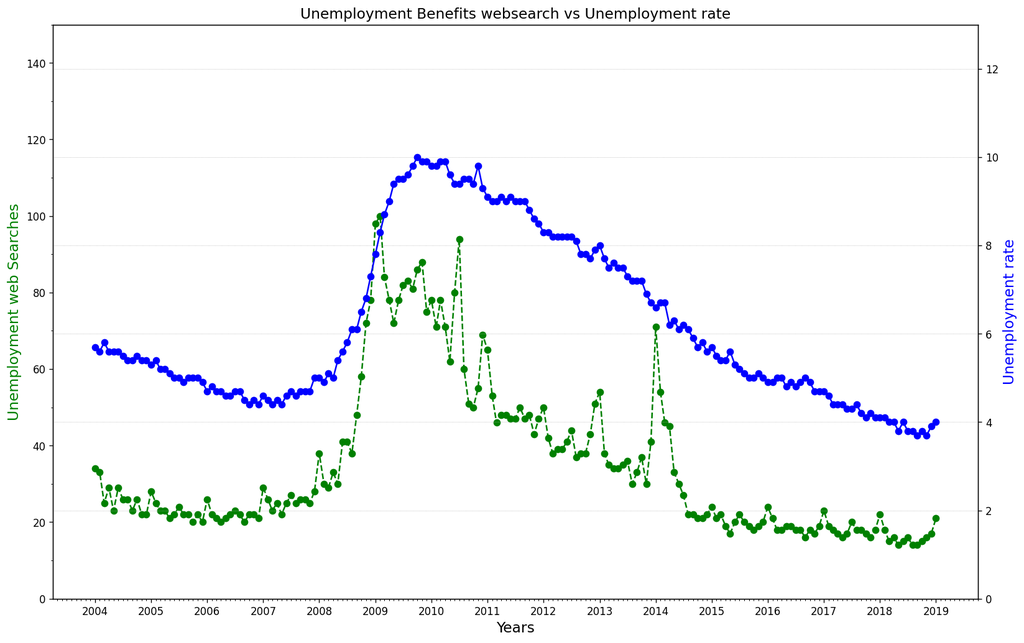

```python
# Diagram code for the USA Unemployment Rates

# The size of the fraphy
plt.figure(figsize=(16,10), dpi =120)

# Title
plt.title("Unemployment Benefits websearch vs Unemployment rate", fontsize = 14)

# Plotting the graph
ax1 =  plt.gca()        # Pulls the stored axis and stores it in ax1
ax2 =  plt.twinx()        # Createds a twin axis and stores it in ax2

ax1.plot(df_unemployment["month"], df_unemployment["web_searches"], color= "g", linestyle = "--", marker  ="o")
ax2.plot(df_unemployment["month"], df_unemployment["unemployment_rate"], color= "b", linestyle = "-", marker  ="o")


# Labels
ax1.set_ylabel("Unemployment web Searches", fontsize = 14, color = "g")
ax2.set_ylabel("Unemployment rate", fontsize = 14, color = "b")
ax1.set_xlabel("Years", fontsize= 14)

# Limits/ tickmarks/ gridlines
    # Limits
ax1.set_ylim([0 , 150])
ax2.set_ylim([0, 13])


    # Tickmarks  on the x ands Y axis
import matplotlib.dates as mdates

years = mdates.YearLocator()            # Locates the months and the years
months = mdates.MonthLocator()
years_fmt = mdates.DateFormatter("%Y")  # Formats the year to the DDDD format

ax1.xaxis.set_major_locator(years)
ax1.xaxis.set_major_formatter(years_fmt)
ax1.xaxis.set_minor_locator(months)


            # Y axis tickers
import matplotlib.ticker as ticker
ax1.yaxis.set_major_locator(ticker.MultipleLocator(20))
ax1.yaxis.set_minor_locator(ticker.MultipleLocator(10))


    # Gridlines
plt.grid(visible = True,axis = "both", which  = "both",  linestyle  =":", linewidth = 0.5)
```

```
     web_searches  unemployment_rate
0             NaN                NaN
1             NaN                NaN
2             NaN                NaN
3             NaN                NaN
4             NaN                NaN
..            ...                ...
176     14.833333           3.850000
177     14.666667           3.816667
178     15.000000           3.800000
179     15.333333           3.783333
180     16.166667           3.816667

[181 rows x 2 columns]
```

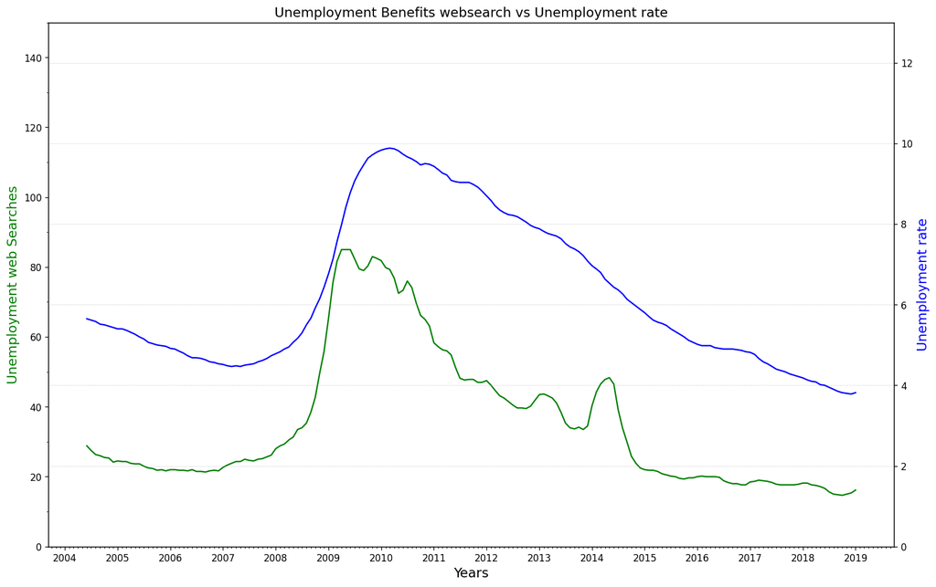

```python
#==================================================================================================Same code using the rolling average function =====================================================================================#

roll_df= df_unemployment[["web_searches", "unemployment_rate"]].rolling(window = 6).mean()
print(roll_df)

                                                        # Every value will be the averager of the past 6. Therefore, the first 5 values will be NAN. Therefore the dates fill in together

# The size of the fraphy
plt.figure(figsize=(16,10), dpi =120)

# Title
plt.title("Unemployment Benefits websearch vs Unemployment rate", fontsize = 14)



# Plotting the graph
ax1 =  plt.gca()        # Pulls the stored axis and stores it in ax1
ax2 =  plt.twinx()        # Createds a twin axis and stores it in ax2

ax1.plot(df_unemployment["month"],roll_df["web_searches"], color= "g")
ax2.plot(df_unemployment["month"], roll_df["unemployment_rate"], color= "b", linestyle = "-")


# Labels
ax1.set_ylabel("Unemployment web Searches", fontsize = 14, color = "g")
ax2.set_ylabel("Unemployment rate", fontsize = 14, color = "b")
ax1.set_xlabel("Years", fontsize= 14)

# Limits/ tickmarks/ gridlines
    # Limits
ax1.set_ylim([0 , 150])
ax2.set_ylim([0, 13])


    # Tickmarks  on the x ands Y axis
import matplotlib.dates as mdates

years = mdates.YearLocator()            # Locates the months and the years
months = mdates.MonthLocator()
years_fmt = mdates.DateFormatter("%Y")  # Formats the year to the DDDD format

ax1.xaxis.set_major_locator(years)
ax1.xaxis.set_major_formatter(years_fmt)
ax1.xaxis.set_minor_locator(months)


            # Y axis tickers
import matplotlib.ticker as ticker
ax1.yaxis.set_major_locator(ticker.MultipleLocator(20))
ax1.yaxis.set_minor_locator(ticker.MultipleLocator(10))


#     # Gridlines
plt.grid(visible = True,axis = "both", which  = "both",  linestyle  =":", linewidth = 0.5)
```